# RLisbona_MSDS6306_Unit6Casestudy

Randy Lisbona

6/18/2016

## 0.1 Unit 6 Case study

Download, clean, merge, analyze Worldbank GDP and Income group data. The purpose of this study was compare Worldbank GDP Rank with Worldbank Incomegroup datasets by countrycode. Questions this study addresses: 1) How many CountryCodes are in both datasets 2) 13th country by ascending GDP Rank. Note -There is no single country with a “13” ranking, but two that share ranking 12.5. 3) What are average GDP Rankings of High Income: OECD and High Income nonOECD groups? Information on OECD (Organization for Economic Cooperation and Development) countries can be found at http://www.oecd.org/ and a list of OECD countries can be found here http://www.oecd.org/about/membersandpartners/list-oecd-member-countries.htm

## 0.2 Download GDP and Income group data sets

GDP source https://d396qusza40orc.cloudfront.net/getdata%2Fdata%2FGDP.csv Income group source https://d396qusza40orc.cloudfront.net/getdata%2Fdata%2FEDSTATS_Country.csv

In this code section the data is downloaded from the above URL’s and saved to local .csv files At this stage the data is raw, no rows or columns have been modified or removed.

```r
source("./Analysis/GatherWorldBankData.R", echo = TRUE,print.eval=TRUE)
```

```
##
## > casestudy.link.GDP <- c("https://d396qusza40orc.cloudfront.net/getdata%2Fdata%2FGDP.csv")
##
## > casestudy.link.IncomeGroupByCountry <- c("https://d396qusza40orc.cloudfront.net/getdata%2Fdata%2FEDSTATS_Country.csv")
##
## > source.url = casestudy.link.GDP
##
## > relativeSourcePath = c("./Analysis/Data")
##
## > GDP.filename = c("GDPbyCountry_raw.csv")
##
## > GDP.pathtofile <- paste(relativeSourcePath, GDP.filename,
## +     sep = "/")
##
## > paste("Downloading file ", GDP.pathtofile, sep = "")
## [1] "Downloading file ./Analysis/Data/GDPbyCountry_raw.csv"
##
## > paste("From URL ", source.url, sep = "")
## [1] "From URL https://d396qusza40orc.cloudfront.net/getdata%2Fdata%2FGDP.csv"
##
## > if (!file.exists(GDP.pathtofile)) download(source.url,
## +     GDP.pathtofile)
##
## > source.url = casestudy.link.IncomeGroupByCountry
##
## > IG.filename = c("IncomeGroupByCountry_raw.csv")
##
## > IG.pathtofile <- paste(relativeSourcePath, IG.filename,
## +     sep = "/")
##
## > paste("Downloading file ", IG.pathtofile, sep = "")
## [1] "Downloading file ./Analysis/Data/IncomeGroupByCountry_raw.csv"
##
## > paste("From URL ", source.url, sep = "")
## [1] "From URL https://d396qusza40orc.cloudfront.net/getdata%2Fdata%2FEDSTATS_Country.csv"
##
## > if (!file.exists(IG.pathtofile)) download(source.url,
## +     IG.pathtofile)
```

## 0.3 Clean raw source data

Cleaning steps include opening the raw source files, visually browsing the files to get a better understanding of quirks in the formatting, steps to extract and verify rows and columns to exclude. Finally outputing and saving cleaned datasets for further analysis in this project as well as future projects that might make use of the same data sources.

```r
source("./Analysis/CleanWorldBankData.R", echo = TRUE,print.eval=TRUE)
```

```
##
## > GDP.raw <- read.csv(GDP.pathtofile, skip = 0, strip.white = TRUE,
## +     blank.lines.skip = TRUE, colClasses = "character")
##
## > paste(nrow(GDP.raw), "Records read from:", GDP.pathtofile,
## +     sep = " ")
## [1] "330 Records read from: ./Analysis/Data/GDPbyCountry_raw.csv"
##
## > IG.raw <- read.csv(IG.pathtofile, strip.white = TRUE,
## +     blank.lines.skip = TRUE, colClasses = "character")
##
## > paste(nrow(IG.raw), "Records read from:", IG.pathtofile,
## +     sep = " ")
## [1] "234 Records read from: ./Analysis/Data/IncomeGroupByCountry_raw.csv"
##
## > GDP_DataRows <- GDP.raw[5:194, ]
##
## > GDP_DataRowsValidCols <- GDP_DataRows[, c(1, 2, 4,
## +     5)]
##
## > names(GDP_DataRowsValidCols) <- c("CountryCode", "Ranking",
## +     "CountryName", "GDP_Millions_USD")
##
## > GDP_DataRowsValidCols$GDP_Millions_USD <- gsub(",",
## +     "", GDP_DataRowsValidCols$GDP_Millions_USD)
##
## > GDP_DataRowsValidCols$GDP_Millions_USD <- as.numeric(GDP_DataRowsValidCols$GDP_Millions_USD)
##
## > GDP_Clean <- GDP_DataRowsValidCols
##
## > IG.reduced <- IG.raw[c(1, 2, 3)]
##
## > names(IG.reduced) <- c("CountryCode", "CountryName",
## +     "IncomeGroup")
##
## > paste(nrow(IG.reduced), "Rows found in Income group dataset before removing blank IncomeGroups",
## +     sep = " ")
## [1] "234 Rows found in Income group dataset before removing blank IncomeGroups"
##
## > IG_Removed <- IG.reduced[IG.reduced$IncomeGroup ==
```

[output cut: 26 more lines]

```
##
## > write.csv(GDP_Clean, file = pathtofile)
##
## > relativeSourcePath = c("./Analysis/Data")
##
## > filename = c("IncomeGroupByCountry_Clean.csv")
##
## > pathtofile <- paste(relativeSourcePath, filename,
## +     sep = "/")
##
## > paste("Write cleaned Income Group :", pathtofile,
## +     sep = " ")
## [1] "Write cleaned Income Group : ./Analysis/Data/IncomeGroupByCountry_Clean.csv"
##
## > write.csv(IG_Clean, file = pathtofile)
```

## 0.4 Merge the GDP and Income group datasets

Merging involved identifying a field common to both the GDP cleaned data and Income Group cleaned data files. Countrycode was common to both files and used as the matching field. inner and outer joins were run to understand missing fields in the combined dataset.

```r
# Merge the data
source("./Analysis/MergeWorldBankData.R", echo = TRUE, print.eval=TRUE)
```

```
##
## > relativeSourcePath = c("./Analysis/Data")
##
## > filename = c("GDPbyCountry_Clean.csv")
##
## > pathtofile <- paste(relativeSourcePath, filename,
## +     sep = "/")
##
## > GDP = read.csv(pathtofile, stringsAsFactors = FALSE)
##
## > paste(nrow(GDP), "Records read from ", pathtofile,
## +     sep = " ")
## [1] "190 Records read from  ./Analysis/Data/GDPbyCountry_Clean.csv"
##
## > filename = c("IncomeGroupbyCountry_Clean.csv")
##
## > pathtofile <- paste(relativeSourcePath, filename,
## +     sep = "/")
##
## > IG = read.csv(pathtofile, stringsAsFactors = FALSE)
##
## > paste(nrow(IG), "Records read from ", pathtofile,
## +     sep = " ")
## [1] "210 Records read from  ./Analysis/Data/IncomeGroupbyCountry_Clean.csv"
##
## > GDP_sub.set <- GDP
##
## > IG_sub.set <- IG
##
## > fulljoin <- full_join(GDP_sub.set, IG_sub.set, by = "CountryCode")
##
## > innerjoin_GDP_IG <- inner_join(GDP_sub.set, IG_sub.set,
## +     by = "CountryCode")
##
## > unmatched_rows <- fulljoin %>% filter(is.na(CountryName.x) |
## +     is.na(IncomeGroup))
```

## 0.5 Analyze the results

The analysis step consists of code necessary to answer the specific questions for the case study

```r
source("./Analysis/AnalyzeWorldBankData.R", echo = TRUE, print.eval=TRUE)
```

```
##
## > paste("Distinct Incomegroups found in dataset", sep = "")
## [1] "Distinct Incomegroups found in dataset"
##
## > distinct(select(innerjoin_GDP_IG, IncomeGroup))
##            IncomeGroup
## 1    High income: OECD
## 2  Lower middle income
## 3  Upper middle income
## 4 High income: nonOECD
## 5           Low income
##
## > paste("Question 1, Match the data based on Countrycodes, how many match both datasets =",
## +     nrow(innerjoin_GDP_IG), sep = "")
## [1] "Question 1, Match the data based on Countrycodes, how many match both datasets =189"
##
## > paste("Count of Countries excluded due to incomplete data = ",
## +     nrow(fulljoin) - nrow(innerjoin_GDP_IG), sep = "")
## [1] "Count of Countries excluded due to incomplete data = 22"
##
## > paste("Table of Unmatched rows", sep = "")
## [1] "Table of Unmatched rows"
##
## > unmatched_rows
##    X.x CountryCode Ranking CountryName.x GDP_Millions_USD X.y                                CountryName.y          IncomeGroup
## 1  135         SSD     131   South Sudan            10220  NA                                         <NA>                 <NA>
## 2   NA         ADO      NA          <NA>               NA   2                      Principality of Andorra High income: nonOECD
## 3   NA         ASM      NA          <NA>               NA   9                               American Samoa  Upper middle income
## 4   NA         CHI      NA          <NA>               NA  35                              Channel Islands High income: nonOECD
## 5   NA         CYM      NA          <NA>               NA  46                               Cayman Islands High income: nonOECD
## 6   NA         DJI      NA          <NA>               NA  50                         Republic of Djibouti  Lower middle income
## 7   NA         FRO      NA          <NA>               NA  64                               Faeroe Islands High income: nonOECD
## 8   NA         GRL      NA          <NA>               NA  76                                    Greenland High income: nonOECD
## 9   NA         GUM      NA          <NA>               NA  78                                         Guam High income: nonOECD
## 10  NA         IMY      NA          <NA>               NA  86                                  Isle of Man High income: nonOECD
## 11  NA         LBY      NA          <NA>               NA 109    Socialist People's Libyan Arab Jamahiriya  Upper middle income
## 12  NA         LIE      NA          <NA>               NA 111                Principality of Liechtenstein High income: nonOECD
## 13  NA         MMR      NA          <NA>               NA 128                             Union of Myanmar           Low income
## 14  NA         MNP      NA          <NA>               NA 131 Commonwealth of the Northern Mariana Islands High income: nonOECD
## 15  NA         NCL      NA          <NA>               NA 138                                New Caledonia High income: nonOECD
```

[output cut: 72 more lines]

```
##
##            IncomeGroup meanrank medianrank
##                  (chr)    (dbl)      (dbl)
## 1 High income: nonOECD 91.91304       94.0
## 2    High income: OECD 32.96667       24.5
##
## > PlotDataset$CountryCode_alpha <- PlotDataset$CountryCode
##
## > PlotDataset$CountryCode <- factor(PlotDataset$CountryCode,
## +     levels = PlotDataset$CountryCode[order(PlotDataset$Ranking)])
##
## > p <- ggplot(data = PlotDataset, aes(x = CountryCode_alpha,
## +     y = GDP_Millions_USD, colour = IncomeGroup)) + geom_point(aes(size = desc(Ranking) .... [TRUNCATED]
##
## > print(p)
```

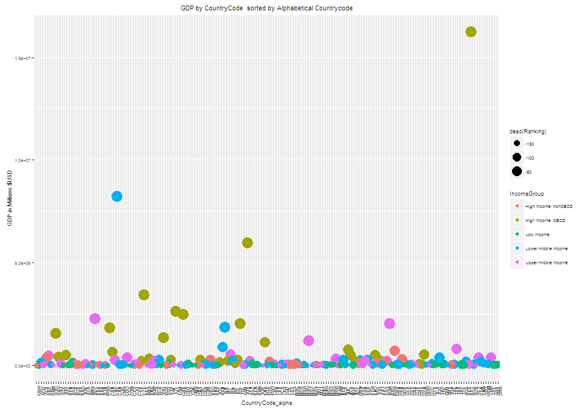

```
##
## > p <- ggplot(data = PlotDataset, aes(x = CountryCode_alpha,
## +     y = GDP_Millions_USD, colour = IncomeGroup)) + geom_point(aes(size = desc(Ranking) .... [TRUNCATED]
##
## > print(p)
```

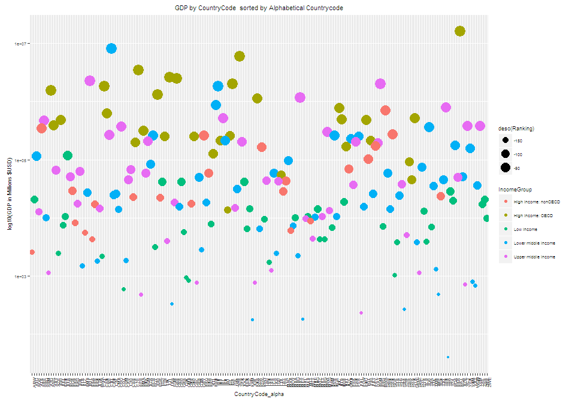

```
##
## > p <- ggplot(data = PlotDataset, aes(x = CountryCode,
## +     y = GDP_Millions_USD, colour = IncomeGroup)) + geom_point(aes(size = desc(Ranking))) +
##  .... [TRUNCATED]
##
## > print(p)
```

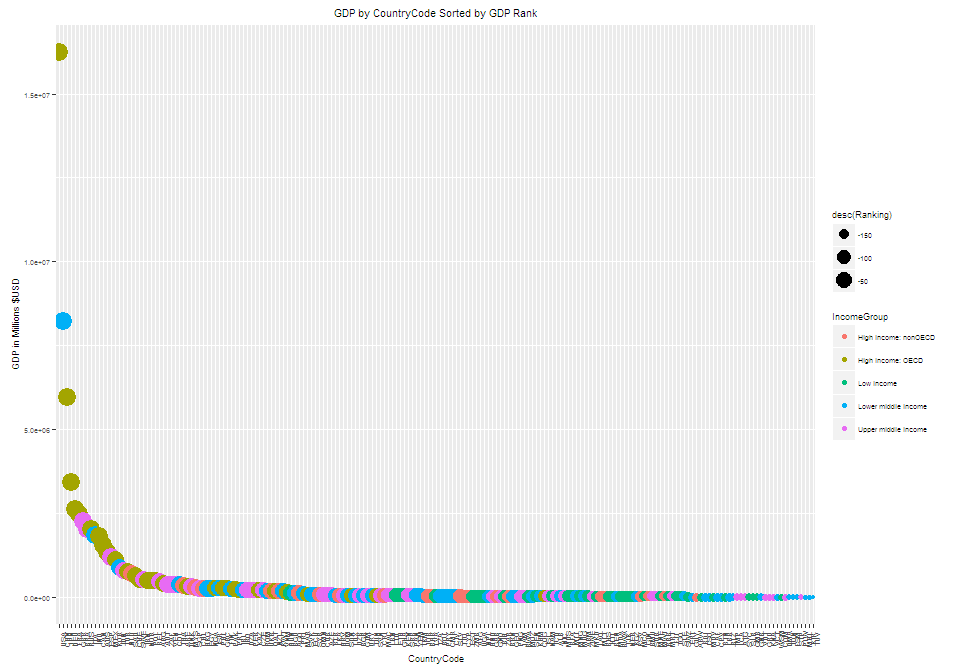

```
##
## > p <- ggplot(data = PlotDataset, aes(x = CountryCode,
## +     y = GDP_Millions_USD, colour = IncomeGroup)) + geom_point(aes(size = desc(Ranking))) +
##  .... [TRUNCATED]
##
## > print(p)
```

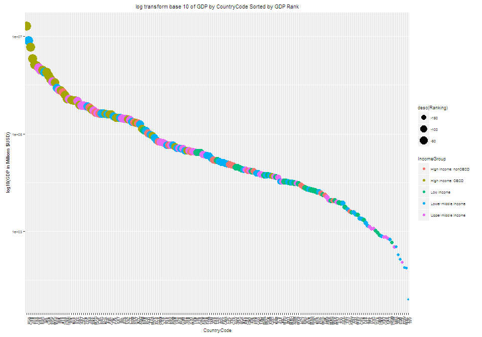

```
##
## > PlotDataset$Quantile <- ntile(PlotDataset$Ranking,
## +     5)
##
## > summary_tbl2 <- ddply(PlotDataset, c("Quantile", "IncomeGroup"),
## +     summarise, N = length(X.x), mean_rank = mean(Ranking), sd_GDP_Millions = sd( .... [TRUNCATED]
##
## > summary_tbl2
##    Quantile          IncomeGroup  N mean_rank sd_GDP_Millions min_GDP    mean_GDP  max_GDP
## 1         1 High income: nonOECD  4  30.75000      211180.083  263259  399401.250   711050
## 2         1    High income: OECD 18  15.00000     3742064.198  314887 2369223.833 16244600
## 3         1  Lower middle income  5  19.40000     3363478.024  262832 2315130.800  8227103
## 4         1  Upper middle income 11  22.81818      705252.385  269869  812226.455  2252664
## 5         2 High income: nonOECD  5  61.60000       51452.754   59228  112617.000   171476
## 6         2    High income: OECD 10  51.70000       70239.523   55178  181262.700   258217
## 7         2           Low income  1  59.00000             NaN  116355  116355.000   116355
## 8         2  Lower middle income 13  57.69231       77489.648   51113  139805.923   262597
## 9         2  Upper middle income  9  61.22222       73946.529   50972  123770.667   205789
## 10        3 High income: nonOECD  8  99.75000        8481.791   16954   25515.875    43582
## 11        3    High income: OECD  1  80.00000             NaN   45279   45279.000    45279
## 12        3           Low income  9  98.55556       10491.696   17204   27608.667    41605
## 13        3  Lower middle income 12  95.08333       10303.698   15747   29858.750    50234
## 14        3  Upper middle income  8  90.37500       12077.362   17466   36237.250    49920
## 15        4 High income: nonOECD  5 144.80000        1874.914    4225    6529.000     8722
## 16        4    High income: OECD  1 122.00000             NaN   13579   13579.000    13579
## 17        4           Low income 16 135.87500        2941.448    4264    8983.250    14244
## 18        4  Lower middle income  8 128.87500        3268.195    6445   10975.625    15654
## 19        4  Upper middle income  8 130.50000        4031.741    4373   10557.875    14755
## 20        5 High income: nonOECD  1 161.00000             NaN    2584    2584.000     2584
## 21        5           Low income 11 166.18182        1332.547     596    2239.455     4199
## 22        5  Lower middle income 16 174.81250        1111.897      40    1286.688     3744
## 23        5  Upper middle income  9 175.22222        1083.887     228    1151.667     3908
##
## > PlotDataset <- mutate(PlotDataset, LMincomeTop38 = (Ranking <=
## +     38) * (IncomeGroup == "Lower middle income"))
##
## > LMincomeTop38.tbl <- PlotDataset[PlotDataset$LMincomeTop38 ==
## +     1, ]
##
## > paste(nrow(LMincomeTop38.tbl), "Countries are in the top 38 by GDP with Lower Middle Income",
## +     sep = " ")
## [1] "5 Countries are in the top 38 by GDP with Lower Middle Income"
##
## > paste("Countries with Lower middle Income groups in top 38 by GDP rank",
## +     sep = "")
## [1] "Countries with Lower middle Income groups in top 38 by GDP rank"
##
## > kable(LMincomeTop38.tbl[, c(2, 4, 7, 5, 11, 8, 3,
## +     12)], caption = "Countries with Lower middle Income groups in top 38 by GDP rank")
##
##
## Table: Countries with Lower middle Income groups in top 38 by GDP rank
##
##      CountryCode   CountryName.x      CountryName.y                 GDP_Millions_USD   Quantile  IncomeGroup            Ranking   LMincomeTop38
## ---  ------------  -----------------  ---------------------------  -----------------  ---------  --------------------  --------  --------------
## 2    CHN           China              People's Republic of China             8227103          1  Lower middle income          2               1
## 10   IND           India              Republic of India                      1841710          1  Lower middle income         10               1
## 16   IDN           Indonesia          Republic of Indonesia                   878043          1  Lower middle income         16               1
## 31   THA           Thailand           Kingdom of Thailand                     365966          1  Lower middle income         31               1
## 38   EGY           Egypt, Arab Rep.   Arab Republic of Egypt                  262832          1  Lower middle income         38               1
```

## 0.6 Conclusion and summary

There was interest in finding the 13th country, ranked by Ascending GDP rank (so USA is last) likely because there is no 13th country. Two countries, Grenada (GRD), and St. Kitts and Nevis (KNA), share rank 12 (denoted as 12.5). Average GDP rankings were calculated for High Income: OECD and High Income: nonOECD countries, OECD countries show a higher GDP rank (lower numbers are higher ranks)

Plots were produced to visually show the GDP rank of the income groups. Significant effort, bordering on ridiculous, was spent learning the idiosyncrasies of ggplot involved with getting the X axis country codes to sort by descending $GDP rather than alphabetically. This groups the OECD countries and higher GDP in the upper left quadrant of charts 3 and 4. Log transform plots were also included to bring the high GDP and low GDP countries closer together on the Y axis plots.

A table of GDP rankings (5 quantiles) was created, along with Frequency of income groups, SD/min/mean/max. There appears to be a significant GDP advantage to OECD member countries, further analysis would need to be performed to verify this through acceptable statistical methods using tedious sofware such as R or SAS.

Five countries were found in the top 38 countries by $GDP with Lower middle income groups. Likely due to low wages in these countries.

## 0.7 Further analysis

Output graphics from R were disappointing, due to time constraints, it was not possible to fit the plots to the page width or rotate the page to landscape orientation so the country codes on the X axis did not land on top of each other. Graphics output was better in R studio than in the HTML output. Seemingly simple tasks are exceedingly difficult in R. Table formatting would need to be improved for publication quality graphics. This was a challenging project.